# Introduction

Domestic flight delays can cost billion dollars to passengers, airlines yearly. Much of this burden along with aggravation comes at the cost of passengers who not only lose time waiting for their planes to leave, but they also miss connecting flights. The question then is, what are the causes for these delays? We are going to analyze combined datasets from the years 2009 to 2018, containing up to 60,000,000 different internal flights in the US. Part One will take on data engineering and review their historical information via data exploration. Part two will continue in another notebook and will use classification models to predict which flights are most likely to arrive late and what are the causes.

AWS EMR-7.0.0 was used for this project. Applications: Hadoop 3.3.6, JupyterEnterpriseGateway 2.6.0, JupyterHub 1.5.0, Livy 0.7.1, Spark 3.5.0, PySpark 3.5

The data sets were downloaded from Kaggle. They can be viewed by going to the following link:

https://www.kaggle.com/datasets/yuanyuwendymu/airline-delay-and-cancellation-data-2009-2018

# Data Review

## Data Dictionary

CRS-Computer Reservation System ArrDel15-Arrival Delay Indicator, flight arrived 15 Minutes or More past CRS Sheduled Arrival. (0=No, 1=Yes)

DepDel15-Departure Delay Indicator, flight depaerted 15 Minutes or More past CRS scheduled departure time. (0=No, 1=Yes)

OP_CARRIER-Airline carrier code

ORIGIN-Airport flight departed.

CRS_DEP_TIME- Departure Time scheduled by CRS.

DEP_TIME-Actual Departure Time (local time: hhmm) It's important to note that the departure time is the moment a plane pushes back from the gate, not the time it takes off.

DEP_DELAY-Difference in minutes between scheduled and actual departure time. Early departures show negative numbers.

WHEELS_OF-Actual Take-Off Time

WHEELS_On-Actual landing Time

TAXI_OUT-The time elapsed between departure from the origin airport gate and wheels off, in minutes.

TAXI_IN-Taxi time from wheels down to arrival at the gate, in minutes.

CRS_ARR_TIME-Arrival time as scheduled in CRS.

ARR_TIME-Actual Arrival Time (local time: hhmm)

ARR_DELAY-Difference in minutes between scheduled and actual arrival time. Early arrivals show negative numbers.

CANCELLED-Flight Canceled. Indicator (0=No,1=Yes)

DIVERTED-Flight landed at different airport than origianl scheduled airport.

CRS_ELAPSED_TIME-Expected elapsed Time of Flight per CRS, in Minutes

CTUAL_ELAPSED_TIME-Actual Elapsed Time of flight, in Minutes.

AIR_TIME-Flight Time, in Minutes

DISTANCE-Distance between airports (miles)

CARRIER_DELAY-Carrier Delay, in Minutes. Carrier delay is within the control of the air carrier. Examples of occurrences that may determine carrier delay are: aircraft cleaning, aircraft damage, awaiting the arrival of connecting passengers or crew, baggage, bird strike, cargo loading, catering, computer, outage-carrier equipment, crew legality (pilot or attendant rest), damage by hazardous goods, engineering inspection, fueling, handling disabled passengers, late crew, lavatory servicing, maintenance, oversales, potable water servicing, removal of unruly passenger, slow boarding or seating, stowing carry-on baggage, weight and balance delays.

WEATHER_DELAY-Weather Delay, in Minutes. Weather delay is caused by extreme or hazardous weather conditions that are forecasted or manifest themselves on point of departure, enroute, or on point of arrival.

NAS_DELAY-National Air System Delay, in Minutes.Delay that is within the control of the National Airspace System (NAS) may include: non-extreme weather conditions, airport operations, heavy traffic volume, air traffic control, etc. Delays that occur after Actual Gate Out are usually attributed to the NAS and are also reported through OPSNET.

SECURITY_DELAY-Security Delay, in Minutes. Security delay is caused by evacuation of a terminal or concourse, re-boarding of aircraft because of security breach, inoperative screening equipment and/or long lines in excess of 29 minutes at screening areas.

LATE_AIRCRAFT_DELAY-Late Aircraft Delay, in Minutes. Arrival delay at an airport due to the late arrival of the same aircraft at a previous airport. The ripple effect of an earlier delay at downstream airports is referred to as delay propagation.

schDepWhOffDiff-Difference between scheduled departure time and wheels up.

wheOnScArrDiff-Difference between wheels down and scheduled arrival time.

DayOfWeek-1 (Monday) - 7 (Sunday)

DayOfMonth-1-31

Month-1-12

DepartureDelayGroups-Departure Delay intervals, every (15 minutes from <-15 to >180). Negative observations are set to zero.

0 Delay between 0 and 14 minutes 1 Delay between 15 to 29 minutes 2 Delay between 30 to 44 minutes 3 Delay between 45 to 59 minutes 4 Delay between 60 to 74 minutes 5 Delay between 75 to 89 minutes 6 Delay between 90 to 104 minutes 7 Delay between 105 to 119 minutes 8 Delay between 120 to 134 minutes 9 Delay between 135 to 149 minutes 10 Delay between 150 to 164 minutes 11 Delay between 165 to 179 minutes 12 Delay >= 180 minutes

DepTimeBlk-CRS Departure Time Block, Hourly Intervals

1--001-0559 12:00AM to 5:59AM 2--0600-0659 6:00AM to 6:59AM 3--0700-0759 7:00AM to 7:59AM 4--0800-0859 8:00AM to 8:59AM 5--0900-0959 9:00AM to 9:59AM 6--1000-1059 10:00AM to 10:59AM 7--1100-1159 11:00AM to 11:59AM 8--1200-1259 12:00PM to 12:59PM 9--1300-1359 1:00PM to 1:59PM 10--1400-1459 2:00PM to 2:59PM 11--1500-1559 3:00PM to 3:59PM 12--1600-1659 4:00PM to 4:59PM 13--1700-1759 5:00PM to 5:59PM 14--1800-1859 6:00PM to 6:59PM 15--1900-1959 7:00PM to 7:59PM 16--2000-2059 8:00PM to 8:59PM 17--2100-2159 9:00PM to 9:59PM 18--2200-2259 10:00PM to 10:59PM 19--2300-2359 11:00PM to 11:59PM

DistanceGroup-Distance Intervals, every 250 Miles, for Flight Segment

1--Less Than 250 Miles 2--250-499 Miles 3--500-749 Miles 4--750-999 Miles 5--1000-1249 Miles 6--1250-1499 Miles 7--1500-1749 Miles 8--1750-1999 Miles 9--2000-2249 Miles 10--2250-2499 Miles 11--500 Miles and Greater

## Start Spark Session and Read in Data

```python
import pyspark
from pyspark.sql import SparkSession
from pyspark.conf import SparkConf
```

```
VBox()
```

```
FloatProgress(value=0.0, bar_style='info', description='Progress:', layout=Layout(height='25px', width='50%'),…
```

```python
conf = SparkConf().setAppName("flightDelay_analysis").setMaster("local[2]") .set("spark.executor.memory", "30g")
```

```
VBox()
```

```
FloatProgress(value=0.0, bar_style='info', description='Progress:', layout=Layout(height='25px', width='50%'),…
```

```python
spark = SparkSession.builder.config(conf=conf).getOrCreate()
```

```
VBox()
```

```
FloatProgress(value=0.0, bar_style='info', description='Progress:', layout=Layout(height='25px', width='50%'),…
```

```python
import pandas as pd
import numpy as np
import matplotlib.pyplot as plt
from scipy.stats import chi2_contingency
import seaborn as sns
```

```
VBox()
```

```
FloatProgress(value=0.0, bar_style='info', description='Progress:', layout=Layout(height='25px', width='50%'),…
```

```python
from pyspark.ml.linalg import Vectors

from pyspark.ml.param import Param, Params
from pyspark.sql.functions import col, desc
from pyspark.sql.functions import pandas_udf


from pyspark.sql.types import StringType,BooleanType,IntegerType,DoubleType,StructType,StructField,LongType,ShortType

from pyspark.ml.feature import VectorAssembler,MinMaxScaler, StandardScaler

from pyspark.ml import Pipeline

from pyspark.mllib.evaluation import BinaryClassificationMetrics, MulticlassMetrics
```

```
VBox()
```

```
FloatProgress(value=0.0, bar_style='info', description='Progress:', layout=Layout(height='25px', width='50%'),…
```

```python
from pyspark.ml.feature import StringIndexer,OneHotEncoder


from pyspark.ml.classification import LogisticRegression,DecisionTreeClassifier,GBTClassifier,RandomForestClassifier,LinearSVC


from pyspark.ml.evaluation import BinaryClassificationEvaluator,MulticlassClassificationEvaluator


import pyspark.ml.evaluation as evals

from pyspark.ml.tuning import CrossValidator, ParamGridBuilder,CrossValidatorModel

from pyspark.ml.stat import Correlation

from pyspark.sql.functions import *

from pyspark.sql.window import *
from pyspark.sql.functions import row_number

import itertools
```

```
VBox()
```

```
FloatProgress(value=0.0, bar_style='info', description='Progress:', layout=Layout(height='25px', width='50%'),…
```

```python
from pyspark.sql import SQLContext
```

```
VBox()
```

```
FloatProgress(value=0.0, bar_style='info', description='Progress:', layout=Layout(height='25px', width='50%'),…
```

```python
pd.set_option("display.max_rows", None)
```

```
VBox()
```

```
FloatProgress(value=0.0, bar_style='info', description='Progress:', layout=Layout(height='25px', width='50%'),…
```

```python
flight_arr = spark.read.csv('s3://arrival-raw-data/*.csv',
                         sep=',',
                         header=True,
                         inferSchema=True,
                         nullValue='NA')
```

```
VBox()
```

```
FloatProgress(value=0.0, bar_style='info', description='Progress:', layout=Layout(height='25px', width='50%'),…
```

```python
flight_arr.count()
```

```
VBox()
```

```
FloatProgress(value=0.0, bar_style='info', description='Progress:', layout=Layout(height='25px', width='50%'),…
```

```
61556964
```

```python
flight_arr.printSchema()
```

```
VBox()
```

```
FloatProgress(value=0.0, bar_style='info', description='Progress:', layout=Layout(height='25px', width='50%'),…
```

```
root
 |-- FL_DATE: date (nullable = true)
 |-- OP_CARRIER: string (nullable = true)
 |-- OP_CARRIER_FL_NUM: integer (nullable = true)
 |-- ORIGIN: string (nullable = true)
 |-- DEST: string (nullable = true)
 |-- CRS_DEP_TIME: double (nullable = true)
 |-- DEP_TIME: double (nullable = true)
 |-- DEP_DELAY: double (nullable = true)
 |-- TAXI_OUT: double (nullable = true)
 |-- WHEELS_OFF: double (nullable = true)
 |-- WHEELS_ON: double (nullable = true)
 |-- TAXI_IN: double (nullable = true)
 |-- CRS_ARR_TIME: double (nullable = true)
 |-- ARR_TIME: double (nullable = true)
 |-- ARR_DELAY: double (nullable = true)
 |-- CANCELLED: double (nullable = true)
 |-- CANCELLATION_CODE: string (nullable = true)
 |-- DIVERTED: double (nullable = true)
 |-- CRS_ELAPSED_TIME: double (nullable = true)
 |-- ACTUAL_ELAPSED_TIME: double (nullable = true)
 |-- AIR_TIME: double (nullable = true)
 |-- DISTANCE: double (nullable = true)
 |-- CARRIER_DELAY: double (nullable = true)
 |-- WEATHER_DELAY: double (nullable = true)
 |-- NAS_DELAY: double (nullable = true)
 |-- SECURITY_DELAY: double (nullable = true)
 |-- LATE_AIRCRAFT_DELAY: double (nullable = true)
 |-- Unnamed: 27: string (nullable = true)
```

There are just over sixty-one million rows in the data set. Majority of the features are numeric data types. In the next section we will use certain numeric data types for creating categorical features.

# Feature Engineering

## Feature Creation

We will create an index column for the purpose of merging data frames created for feature creation.

```python
window = Window.orderBy(flight_arr.columns)

flight_2 = flight_arr.withColumn("idx", row_number().over(window))
```

```
VBox()
```

```
FloatProgress(value=0.0, bar_style='info', description='Progress:', layout=Layout(height='25px', width='50%'),…
```

```python
flight_2.select('idx','FL_DATE').show(5)
```

```
VBox()
```

```
FloatProgress(value=0.0, bar_style='info', description='Progress:', layout=Layout(height='25px', width='50%'),…
```

```
+---+----------+
|idx|   FL_DATE|
+---+----------+
|  1|2009-01-01|
|  2|2009-01-01|
|  3|2009-01-01|
|  4|2009-01-01|
|  5|2009-01-01|
+---+----------+
only showing top 5 rows
```

The output displays the new new idx column.

Our first new feature will be the difference between the actual elapsed time of a flight and the elapsed time in the CRS system.

```python
flight_2=flight_2.withColumn("elapTimeDIff",col("ACTUAL_ELAPSED_TIME")-col("CRS_ELAPSED_TIME"))
```

```
VBox()
```

```
FloatProgress(value=0.0, bar_style='info', description='Progress:', layout=Layout(height='25px', width='50%'),…
```

```python
flight_2.select("elapTimeDIff").show(5)
```

```
VBox()
```

```
FloatProgress(value=0.0, bar_style='info', description='Progress:', layout=Layout(height='25px', width='50%'),…
```

```
+------------+
|elapTimeDIff|
+------------+
|         6.0|
|        -7.0|
|        -8.0|
|       -21.0|
|       -28.0|
+------------+
only showing top 5 rows
```

Our next new features will be created by binning (separating into categories) numeric features into groups.

Departure delay groups will be created by binning the DEP_DELAY (departure delay in minutes) feature.

```python
flight_3=flight_2.withColumn('DepartureDelayGroups',
when((col('DEP_DELAY') <= 14),'0')
.when((col('DEP_DELAY') > 14) & (col('DEP_DELAY') <=29), '1')
.when((col('DEP_DELAY') > 29) & (col('DEP_DELAY') <= 44), '2')
.when((col('DEP_DELAY') > 44) & (col('DEP_DELAY') <= 59), '3')
.when((col('DEP_DELAY') > 59) & (col('DEP_DELAY') <= 74), '4')
.when((col('DEP_DELAY')> 74) & (col('DEP_DELAY') <= 89), '5')
.when((col('DEP_DELAY') > 89) & (col('DEP_DELAY') <= 104), '6')
.when((col('DEP_DELAY') > 104) & (col('DEP_DELAY') <= 119), '7')
.when((col('DEP_DELAY') > 119) & (col('DEP_DELAY') <= 134), '8')
.when((col('DEP_DELAY') > 134) & (col('DEP_DELAY') <= 149), '9')
.when((col('DEP_DELAY') > 149) & (col('DEP_DELAY') <= 164), '10')
.when((col('DEP_DELAY') > 164) & (col('DEP_DELAY') <= 179), '11')
.otherwise('12'))
```

```
VBox()
```

```
FloatProgress(value=0.0, bar_style='info', description='Progress:', layout=Layout(height='25px', width='50%'),…
```

```python
flight_3.groupBy('DepartureDelayGroups').count().orderBy('count', ascending=False).show(truncate=False)
```

```
VBox()
```

```
FloatProgress(value=0.0, bar_style='info', description='Progress:', layout=Layout(height='25px', width='50%'),…
```

```
+--------------------+--------+
|DepartureDelayGroups|count   |
+--------------------+--------+
|0                   |49663153|
|1                   |4144304 |
|2                   |2098570 |
|12                  |1427156 |
|3                   |1281143 |
|4                   |856213  |
|5                   |604143  |
|6                   |441594  |
|7                   |330771  |
|8                   |251006  |
|9                   |191613  |
|10                  |150181  |
|11                  |117117  |
+--------------------+--------+
```

The numerical feature CRS_DEP_TIME (scheduled departure time) will be binned into groups.

```python
flight_3=flight_3.withColumn('DepTimeBlk',
when((col('CRS_DEP_TIME') <= 559),'1')
.when((col('CRS_DEP_TIME') > 559) & (col('CRS_DEP_TIME') <=659), '2')
.when((col('CRS_DEP_TIME') > 659) & (col('CRS_DEP_TIME') <= 759), '3')
.when((col('CRS_DEP_TIME') > 759) & (col('CRS_DEP_TIME') <= 859), '4')
.when((col('CRS_DEP_TIME') > 859) & (col('CRS_DEP_TIME') <= 959), '5')
.when((col('CRS_DEP_TIME') > 959) & (col('CRS_DEP_TIME') <= 1059), '6')
.when((col('CRS_DEP_TIME') > 1059) & (col('CRS_DEP_TIME') <= 1159), '7')
.when((col('CRS_DEP_TIME') > 1159) & (col('CRS_DEP_TIME') <= 1259), '8')
.when((col('CRS_DEP_TIME') > 1259) & (col('CRS_DEP_TIME') <= 1359), '9')
.when((col('CRS_DEP_TIME') > 1359) & (col('CRS_DEP_TIME') <= 1459), '10')
.when((col('CRS_DEP_TIME') > 1459) & (col('CRS_DEP_TIME') <= 1559), '11')
.when((col('CRS_DEP_TIME') > 1559) & (col('CRS_DEP_TIME') <= 1659), '12')
.when((col('CRS_DEP_TIME') > 1659) & (col('CRS_DEP_TIME') <= 1759), '13')
.when((col('CRS_DEP_TIME') > 1759) & (col('CRS_DEP_TIME') <= 1859), '14')
.when((col('CRS_DEP_TIME') > 1859) & (col('CRS_DEP_TIME') <= 1959), '15')
.when((col('CRS_DEP_TIME') > 2000) & (col('CRS_DEP_TIME') <= 2059), '16')
.when((col('CRS_DEP_TIME') > 2059) & (col('CRS_DEP_TIME') <= 2159), '17')
.when((col('CRS_DEP_TIME') > 2159) & (col('CRS_DEP_TIME') <= 2259), '18')
.otherwise('19'))
```

```
VBox()
```

```
FloatProgress(value=0.0, bar_style='info', description='Progress:', layout=Layout(height='25px', width='50%'),…
```

```python
flight_3.groupBy('DepTimeBlk').count().orderBy('count', ascending=False).show(truncate=False)
```

```
VBox()
```

```
FloatProgress(value=0.0, bar_style='info', description='Progress:', layout=Layout(height='25px', width='50%'),…
```

```
+----------+-------+
|DepTimeBlk|count  |
+----------+-------+
|2         |4317253|
|4         |4223138|
|3         |4170297|
|13        |4142633|
|7         |3957728|
|6         |3924952|
|9         |3889477|
|8         |3817033|
|11        |3787158|
|5         |3754614|
|12        |3728339|
|10        |3664033|
|14        |3565443|
|15        |3520747|
|16        |2357476|
|17        |1841938|
|18        |1148983|
|1         |1123830|
|19        |621892 |
+----------+-------+
```

We will bin the numerical feature DISTANCE into groups.

```python
flight_3=flight_3.withColumn('DistanceGroup',
when((col('DISTANCE') <= 249),'1')
.when((col('DISTANCE') > 249) & (col('DISTANCE') <=499), '2')
.when((col('DISTANCE') > 499) & (col('DISTANCE') <= 749), '3')
.when((col('DISTANCE') > 749) & (col('DISTANCE') <= 999), '4')
.when((col('DISTANCE') > 999) & (col('DISTANCE') <= 1249), '5')
.when((col('DISTANCE') > 1249) & (col('DISTANCE') <= 1499), '6')
.when((col('DISTANCE') > 1499) & (col('DISTANCE') <= 1749), '7')
.when((col('DISTANCE') > 1749) & (col('DISTANCE') <= 1999), '8')
.when((col('DISTANCE') > 1999) & (col('DISTANCE') <= 2249), '9')
.when((col('DISTANCE') > 2249) & (col('DISTANCE') <= 2499), '10')
.otherwise('11'))
```

```
VBox()
```

```
FloatProgress(value=0.0, bar_style='info', description='Progress:', layout=Layout(height='25px', width='50%'),…
```

```python
flight_3.groupBy('DistanceGroup').count().orderBy('count', ascending=False).show(truncate=False)
```

```
VBox()
```

```
FloatProgress(value=0.0, bar_style='info', description='Progress:', layout=Layout(height='25px', width='50%'),…
```

```
+-------------+--------+
|DistanceGroup|count   |
+-------------+--------+
|2            |15541799|
|3            |12344795|
|4            |9096064 |
|1            |8555150 |
|5            |5931450 |
|7            |2670723 |
|6            |2509869 |
|10           |1511009 |
|8            |1354615 |
|11           |1126630 |
|9            |914860  |
+-------------+--------+
```

Our feature creation and data cleaning will be for creating predicting flight arrival delays using classification models. As such we will require a binary categorical feature. From the data dictionary we know that arrival delays are those flights which arrive 15 minutes or more past the CRS scheduled arrival time. We will use ARR-DELAY for the creation of a new binary feature in which the codes will be "0"(arrived on time), and "1"(arrived late).

```python
flight_3=flight_3.withColumn('ArrDel15',
when((col('ARR_DELAY') <= 14),'0')
.otherwise('1'))
```

```
VBox()
```

```
FloatProgress(value=0.0, bar_style='info', description='Progress:', layout=Layout(height='25px', width='50%'),…
```

```python
flight_3.groupBy('ArrDel15').count().orderBy('count', ascending=False).show(truncate=False)
```

```
VBox()
```

```
FloatProgress(value=0.0, bar_style='info', description='Progress:', layout=Layout(height='25px', width='50%'),…
```

```
+--------+--------+
|ArrDel15|count   |
+--------+--------+
|0       |49044872|
|1       |12512092|
+--------+--------+
```

For purposes on data exploration AS with arrival delays, we will perform the same process for departure delays. This new binary feature will help our data analysis. Flights departing less than 15 minutes late will be codes as "0"(no), and flights departing 15 minutes late or more will be coded as "1"(yes).

```python
flight_3=flight_3.withColumn('DepDel15',
when((col('DEP_DELAY') <= 14),'0')
.otherwise('1'))
```

```
VBox()
```

```
FloatProgress(value=0.0, bar_style='info', description='Progress:', layout=Layout(height='25px', width='50%'),…
```

```python
flight_3.groupBy('DepDel15').count().orderBy('count', ascending=False).show(truncate=False)
```

```
VBox()
```

```
FloatProgress(value=0.0, bar_style='info', description='Progress:', layout=Layout(height='25px', width='50%'),…
```

```
+--------+--------+
|DepDel15|count   |
+--------+--------+
|0       |49663153|
|1       |11893811|
+--------+--------+
```

The creation of our next two features will be accomplished using a SQL query. A temporary SQL table will for creating the SQL queries,

```python
# Register the DataFrame as a temporary SQL table
flight_3.createOrReplaceTempView("time_table")
```

```
VBox()
```

```
FloatProgress(value=0.0, bar_style='info', description='Progress:', layout=Layout(height='25px', width='50%'),…
```

```python
# Define a SQL query to calculate the time difference in minutes
sql_query = """
    SELECT
           idx,
           WHEELS_OFF,
           WHEELS_ON,
           CRS_DEP_TIME,
           CRS_ARR_TIME,
           ABS(CAST(SUBSTRING(lpad(CRS_DEP_TIME, 4, '0'), 1, 2) AS INT) * 60 + CAST(SUBSTRING(lpad(CRS_DEP_TIME, 4, '0'), 3, 2) AS INT) -
               (CAST(SUBSTRING(lpad(WHEELS_OFF, 4, '0'), 1, 2) AS INT) * 60 + CAST(SUBSTRING(lpad(WHEELS_OFF, 4, '0'), 3, 2) AS INT))) AS schDepWhOffDiff,
            ABS(CAST(SUBSTRING(lpad(CRS_ARR_TIME, 4, '0'), 1, 2) AS INT) * 60 + CAST(SUBSTRING(lpad(CRS_ARR_TIME, 4, '0'), 3, 2) AS INT) -
               (CAST(SUBSTRING(lpad(WHEELS_ON, 4, '0'), 1, 2) AS INT) * 60 + CAST(SUBSTRING(lpad(WHEELS_ON, 4, '0'), 3, 2) AS INT))) AS wheOnScArrDiff
    FROM time_table
"""

# Execute the SQL query
result_df = spark.sql(sql_query)
```

```
VBox()
```

```
FloatProgress(value=0.0, bar_style='info', description='Progress:', layout=Layout(height='25px', width='50%'),…
```

```python
result_df.select('schDepWhOffDiff','wheOnScArrDiff').show(5)
```

```
VBox()
```

```
FloatProgress(value=0.0, bar_style='info', description='Progress:', layout=Layout(height='25px', width='50%'),…
```

```
+---------------+--------------+
|schDepWhOffDiff|wheOnScArrDiff|
+---------------+--------------+
|             16|             4|
|             27|            12|
|             19|            15|
|             19|            21|
|             14|            51|
+---------------+--------------+
only showing top 5 rows
```

```python
result_df.printSchema()
```

```
VBox()
```

```
FloatProgress(value=0.0, bar_style='info', description='Progress:', layout=Layout(height='25px', width='50%'),…
```

```
root
 |-- idx: integer (nullable = false)
 |-- WHEELS_OFF: double (nullable = true)
 |-- WHEELS_ON: double (nullable = true)
 |-- CRS_DEP_TIME: double (nullable = true)
 |-- CRS_ARR_TIME: double (nullable = true)
 |-- schDepWhOffDiff: integer (nullable = true)
 |-- wheOnScArrDiff: integer (nullable = true)
```

The result_df data frame will be merged with the flight_3 data frame and to avoid duplicate columns we will drop them from the result_df data frame.

```python
result_df=result_df.drop('WHEELS_OFF','CRS_DEP_TIME','CRS_ARR_TIME','WHEELS_ON')
```

```
VBox()
```

```
FloatProgress(value=0.0, bar_style='info', description='Progress:', layout=Layout(height='25px', width='50%'),…
```

```python
result_df.printSchema()
```

```
VBox()
```

```
FloatProgress(value=0.0, bar_style='info', description='Progress:', layout=Layout(height='25px', width='50%'),…
```

```
root
 |-- idx: integer (nullable = false)
 |-- schDepWhOffDiff: integer (nullable = true)
 |-- wheOnScArrDiff: integer (nullable = true)
```

We will now join the flight_3 data frame with the result_df data frame. The idx will be dropped from flight_3 to prevent duplicate columns.

```python
flight_4=flight_3.join(result_df,flight_3.idx == result_df.idx,"outer").drop(flight_3.idx)
```

```
VBox()
```

```
FloatProgress(value=0.0, bar_style='info', description='Progress:', layout=Layout(height='25px', width='50%'),…
```

```python
flight_4.printSchema()
```

```
VBox()
```

```
FloatProgress(value=0.0, bar_style='info', description='Progress:', layout=Layout(height='25px', width='50%'),…
```

```
root
 |-- FL_DATE: date (nullable = true)
 |-- OP_CARRIER: string (nullable = true)
 |-- OP_CARRIER_FL_NUM: integer (nullable = true)
 |-- ORIGIN: string (nullable = true)
 |-- DEST: string (nullable = true)
 |-- CRS_DEP_TIME: double (nullable = true)
 |-- DEP_TIME: double (nullable = true)
 |-- DEP_DELAY: double (nullable = true)
 |-- TAXI_OUT: double (nullable = true)
 |-- WHEELS_OFF: double (nullable = true)
 |-- WHEELS_ON: double (nullable = true)
 |-- TAXI_IN: double (nullable = true)
 |-- CRS_ARR_TIME: double (nullable = true)
 |-- ARR_TIME: double (nullable = true)
 |-- ARR_DELAY: double (nullable = true)
 |-- CANCELLED: double (nullable = true)
 |-- CANCELLATION_CODE: string (nullable = true)
 |-- DIVERTED: double (nullable = true)
 |-- CRS_ELAPSED_TIME: double (nullable = true)
 |-- ACTUAL_ELAPSED_TIME: double (nullable = true)
 |-- AIR_TIME: double (nullable = true)
 |-- DISTANCE: double (nullable = true)
 |-- CARRIER_DELAY: double (nullable = true)
 |-- WEATHER_DELAY: double (nullable = true)
 |-- NAS_DELAY: double (nullable = true)
 |-- SECURITY_DELAY: double (nullable = true)
 |-- LATE_AIRCRAFT_DELAY: double (nullable = true)
 |-- Unnamed: 27: string (nullable = true)
 |-- elapTimeDIff: double (nullable = true)
 |-- DepartureDelayGroups: string (nullable = true)
 |-- DepTimeBlk: string (nullable = true)
 |-- DistanceGroup: string (nullable = true)
 |-- ArrDel15: string (nullable = true)
 |-- DepDel15: string (nullable = true)
 |-- idx: integer (nullable = true)
 |-- schDepWhOffDiff: integer (nullable = true)
 |-- wheOnScArrDiff: integer (nullable = true)
```

Our next new features will be created from the FL_DATE (flight date) columns. The year, month, day of week and day of month will be extracted for the flight date.

```python
flight_5 = flight_4.withColumn('DayOfWeek',dayofweek(flight_4.FL_DATE))\
                    .withColumn('Month',month(flight_4.FL_DATE))\
                    .withColumn('Year',year(flight_4.FL_DATE))\
                    .withColumn('DayOfMonth',dayofmonth(flight_4.FL_DATE))
```

```
VBox()
```

```
FloatProgress(value=0.0, bar_style='info', description='Progress:', layout=Layout(height='25px', width='50%'),…
```

```python
flight_5.printSchema()
```

```
VBox()
```

```
FloatProgress(value=0.0, bar_style='info', description='Progress:', layout=Layout(height='25px', width='50%'),…
```

```
root
 |-- FL_DATE: date (nullable = true)
 |-- OP_CARRIER: string (nullable = true)
 |-- OP_CARRIER_FL_NUM: integer (nullable = true)
 |-- ORIGIN: string (nullable = true)
 |-- DEST: string (nullable = true)
 |-- CRS_DEP_TIME: double (nullable = true)
 |-- DEP_TIME: double (nullable = true)
 |-- DEP_DELAY: double (nullable = true)
 |-- TAXI_OUT: double (nullable = true)
 |-- WHEELS_OFF: double (nullable = true)
 |-- WHEELS_ON: double (nullable = true)
 |-- TAXI_IN: double (nullable = true)
 |-- CRS_ARR_TIME: double (nullable = true)
 |-- ARR_TIME: double (nullable = true)
 |-- ARR_DELAY: double (nullable = true)
 |-- CANCELLED: double (nullable = true)
 |-- CANCELLATION_CODE: string (nullable = true)
 |-- DIVERTED: double (nullable = true)
 |-- CRS_ELAPSED_TIME: double (nullable = true)
 |-- ACTUAL_ELAPSED_TIME: double (nullable = true)
 |-- AIR_TIME: double (nullable = true)
 |-- DISTANCE: double (nullable = true)
 |-- CARRIER_DELAY: double (nullable = true)
 |-- WEATHER_DELAY: double (nullable = true)
 |-- NAS_DELAY: double (nullable = true)
 |-- SECURITY_DELAY: double (nullable = true)
 |-- LATE_AIRCRAFT_DELAY: double (nullable = true)
 |-- Unnamed: 27: string (nullable = true)
 |-- elapTimeDIff: double (nullable = true)
 |-- DepartureDelayGroups: string (nullable = true)
 |-- DepTimeBlk: string (nullable = true)
 |-- DistanceGroup: string (nullable = true)
 |-- ArrDel15: string (nullable = true)
 |-- DepDel15: string (nullable = true)
 |-- idx: integer (nullable = true)
 |-- schDepWhOffDiff: integer (nullable = true)
 |-- wheOnScArrDiff: integer (nullable = true)
 |-- DayOfWeek: integer (nullable = true)
 |-- Month: integer (nullable = true)
 |-- Year: integer (nullable = true)
 |-- DayOfMonth: integer (nullable = true)
```

```python
flight_5.groupBy('OP_CARRIER').count().orderBy('count', ascending=False).show(truncate=False)
```

```
VBox()
```

```
FloatProgress(value=0.0, bar_style='info', description='Progress:', layout=Layout(height='25px', width='50%'),…
```

```
+----------+--------+
|OP_CARRIER|count   |
+----------+--------+
|WN        |12096540|
|DL        |7841880 |
|AA        |6682161 |
|OO        |6263052 |
|UA        |4826658 |
|EV        |4726445 |
|MQ        |3216260 |
|US        |2657286 |
|B6        |2483969 |
|AS        |1660539 |
|FL        |1218389 |
|XE        |1105864 |
|9E        |1066251 |
|YV        |1063558 |
|F9        |903218  |
|HA        |744991  |
|CO        |740498  |
|NK        |588574  |
|OH        |577060  |
|VX        |389060  |
+----------+--------+
only showing top 20 rows
```

```python
flight_5 = flight_5.withColumn("CarrierName", when(flight_5.OP_CARRIER == 'WN','Southwest Airlines')
                                             .when(flight_5.OP_CARRIER == 'DL','Delta Airlines')
                                             .when(flight_5.OP_CARRIER == 'AA','American Airlines')
                                             .when(flight_5.OP_CARRIER == 'OO','SkyWest Airlines')
                                             .when(flight_5.OP_CARRIER == 'UA','United Airlines')
                                             .when(flight_5.OP_CARRIER == 'EV','Atlantic Southeast Airlines ')
                                             .when(flight_5.OP_CARRIER == 'MQ','Envoy Air')
                                            .when(flight_5.OP_CARRIER == 'B6','JetBlue Airways')
                                            .when(flight_5.OP_CARRIER == 'AS','Alaska Airlines')
                                            .when(flight_5.OP_CARRIER == '9E','Endeavor Air')
                                            .when(flight_5.OP_CARRIER == 'YV','Mesa Airline')
                                            .when(flight_5.OP_CARRIER == 'F9','Frontier Airlines')
                                            .when(flight_5.OP_CARRIER == 'HA','Hawaiian Airlines')
                                            .when(flight_5.OP_CARRIER == 'NK','Spirit Airlines')
                                            .when(flight_5.OP_CARRIER == 'OH','PSA Airlines')
                                            .when(flight_5.OP_CARRIER == 'VX','Virgin America')
                                            .when(flight_5.OP_CARRIER == 'US','US Airways')
                                            .when(flight_5.OP_CARRIER == 'FL','AirTran Airways')
                                            .when(flight_5.OP_CARRIER == 'XE','ExpressJet Airlines')
                                            .otherwise('Continental Airlines'))
```

```
VBox()
```

```
FloatProgress(value=0.0, bar_style='info', description='Progress:', layout=Layout(height='25px', width='50%'),…
```

```python
flight_5.groupBy('CarrierName').count().orderBy('count', ascending=False).show(truncate=False)
```

```
VBox()
```

```
FloatProgress(value=0.0, bar_style='info', description='Progress:', layout=Layout(height='25px', width='50%'),…
```

```
+----------------------------+--------+
|CarrierName                 |count   |
+----------------------------+--------+
|Southwest Airlines          |12096540|
|Delta Airlines              |7841880 |
|American Airlines           |6682161 |
|SkyWest Airlines            |6263052 |
|United Airlines             |4826658 |
|Atlantic Southeast Airlines |4726445 |
|Envoy Air                   |3216260 |
|US Airways                  |2657286 |
|JetBlue Airways             |2483969 |
|Alaska Airlines             |1660539 |
|Continental Airlines        |1445209 |
|AirTran Airways             |1218389 |
|ExpressJet Airlines         |1105864 |
|Endeavor Air                |1066251 |
|Mesa Airline                |1063558 |
|Frontier Airlines           |903218  |
|Hawaiian Airlines           |744991  |
|Spirit Airlines             |588574  |
|PSA Airlines                |577060  |
|Virgin America              |389060  |
+----------------------------+--------+
```

## Data Cleaning

```python
flight_6=flight_5.drop('FL_DATE','OP_CARRIER_FL_NUM','CRS_DEP_TIME','DEP_TIME','WHEELS_OFF','WHEELS_ON','CRS_ARR_TIME','ARR_TIME',
                       'AIR_TIME','DISTANCE')
```

```
VBox()
```

```
FloatProgress(value=0.0, bar_style='info', description='Progress:', layout=Layout(height='25px', width='50%'),…
```

```python
flight_6.printSchema()
```

```
VBox()
```

```
FloatProgress(value=0.0, bar_style='info', description='Progress:', layout=Layout(height='25px', width='50%'),…
```

```
root
 |-- OP_CARRIER: string (nullable = true)
 |-- ORIGIN: string (nullable = true)
 |-- DEST: string (nullable = true)
 |-- DEP_DELAY: double (nullable = true)
 |-- TAXI_OUT: double (nullable = true)
 |-- TAXI_IN: double (nullable = true)
 |-- ARR_DELAY: double (nullable = true)
 |-- CANCELLED: double (nullable = true)
 |-- CANCELLATION_CODE: string (nullable = true)
 |-- DIVERTED: double (nullable = true)
 |-- CRS_ELAPSED_TIME: double (nullable = true)
 |-- ACTUAL_ELAPSED_TIME: double (nullable = true)
 |-- CARRIER_DELAY: double (nullable = true)
 |-- WEATHER_DELAY: double (nullable = true)
 |-- NAS_DELAY: double (nullable = true)
 |-- SECURITY_DELAY: double (nullable = true)
 |-- LATE_AIRCRAFT_DELAY: double (nullable = true)
 |-- Unnamed: 27: string (nullable = true)
 |-- elapTimeDIff: double (nullable = true)
 |-- DepartureDelayGroups: string (nullable = true)
 |-- DepTimeBlk: string (nullable = true)
 |-- DistanceGroup: string (nullable = true)
 |-- ArrDel15: string (nullable = true)
 |-- DepDel15: string (nullable = true)
 |-- idx: integer (nullable = true)
 |-- schDepWhOffDiff: integer (nullable = true)
 |-- wheOnScArrDiff: integer (nullable = true)
 |-- DayOfWeek: integer (nullable = true)
 |-- Month: integer (nullable = true)
 |-- Year: integer (nullable = true)
 |-- DayOfMonth: integer (nullable = true)
 |-- CarrierName: string (nullable = false)
```

```python
flight_7 = flight_6.withColumn("Month",col("Month").cast(StringType())) \
            .withColumn('DayOfMonth',col('DayOfMonth').cast(StringType())) \
            .withColumn('DayOfWeek',col('DayOfWeek').cast(StringType())) \
            .withColumn("CANCELLED",col("CANCELLED").cast(StringType())) \
            .withColumn("DIVERTED",col("DIVERTED").cast(StringType())) \
            .withColumn('Year',col('Year').cast(StringType()))
```

```
VBox()
```

```
FloatProgress(value=0.0, bar_style='info', description='Progress:', layout=Layout(height='25px', width='50%'),…
```

```python
flight_7.printSchema()
```

```
VBox()
```

```
FloatProgress(value=0.0, bar_style='info', description='Progress:', layout=Layout(height='25px', width='50%'),…
```

```
root
 |-- OP_CARRIER: string (nullable = true)
 |-- ORIGIN: string (nullable = true)
 |-- DEST: string (nullable = true)
 |-- DEP_DELAY: double (nullable = true)
 |-- TAXI_OUT: double (nullable = true)
 |-- TAXI_IN: double (nullable = true)
 |-- ARR_DELAY: double (nullable = true)
 |-- CANCELLED: string (nullable = true)
 |-- CANCELLATION_CODE: string (nullable = true)
 |-- DIVERTED: string (nullable = true)
 |-- CRS_ELAPSED_TIME: double (nullable = true)
 |-- ACTUAL_ELAPSED_TIME: double (nullable = true)
 |-- CARRIER_DELAY: double (nullable = true)
 |-- WEATHER_DELAY: double (nullable = true)
 |-- NAS_DELAY: double (nullable = true)
 |-- SECURITY_DELAY: double (nullable = true)
 |-- LATE_AIRCRAFT_DELAY: double (nullable = true)
 |-- Unnamed: 27: string (nullable = true)
 |-- elapTimeDIff: double (nullable = true)
 |-- DepartureDelayGroups: string (nullable = true)
 |-- DepTimeBlk: string (nullable = true)
 |-- DistanceGroup: string (nullable = true)
 |-- ArrDel15: string (nullable = true)
 |-- DepDel15: string (nullable = true)
 |-- idx: integer (nullable = true)
 |-- schDepWhOffDiff: integer (nullable = true)
 |-- wheOnScArrDiff: integer (nullable = true)
 |-- DayOfWeek: string (nullable = true)
 |-- Month: string (nullable = true)
 |-- Year: string (nullable = true)
 |-- DayOfMonth: string (nullable = true)
 |-- CarrierName: string (nullable = false)
```

```python
flight_7.select(flight_7.columns[17]).show()
```

```
VBox()
```

```
FloatProgress(value=0.0, bar_style='info', description='Progress:', layout=Layout(height='25px', width='50%'),…
```

```
+-----------+
|Unnamed: 27|
+-----------+
|       NULL|
|       NULL|
|       NULL|
|       NULL|
|       NULL|
|       NULL|
|       NULL|
|       NULL|
|       NULL|
|       NULL|
|       NULL|
|       NULL|
|       NULL|
|       NULL|
|       NULL|
|       NULL|
|       NULL|
|       NULL|
|       NULL|
|       NULL|
+-----------+
only showing top 20 rows
```

From the schema print output above we find that there is an unnamed column. Closer inspection of the unnamed column finds there are only null values in this column. This column will be dropped.

```python
flight_7=flight_7.drop(flight_7.columns[17])
```

```
VBox()
```

```
FloatProgress(value=0.0, bar_style='info', description='Progress:', layout=Layout(height='25px', width='50%'),…
```

```python
flight_7.printSchema()
```

```
VBox()
```

```
FloatProgress(value=0.0, bar_style='info', description='Progress:', layout=Layout(height='25px', width='50%'),…
```

```
root
 |-- OP_CARRIER: string (nullable = true)
 |-- ORIGIN: string (nullable = true)
 |-- DEST: string (nullable = true)
 |-- DEP_DELAY: double (nullable = true)
 |-- TAXI_OUT: double (nullable = true)
 |-- TAXI_IN: double (nullable = true)
 |-- ARR_DELAY: double (nullable = true)
 |-- CANCELLED: string (nullable = true)
 |-- CANCELLATION_CODE: string (nullable = true)
 |-- DIVERTED: string (nullable = true)
 |-- CRS_ELAPSED_TIME: double (nullable = true)
 |-- ACTUAL_ELAPSED_TIME: double (nullable = true)
 |-- CARRIER_DELAY: double (nullable = true)
 |-- WEATHER_DELAY: double (nullable = true)
 |-- NAS_DELAY: double (nullable = true)
 |-- SECURITY_DELAY: double (nullable = true)
 |-- LATE_AIRCRAFT_DELAY: double (nullable = true)
 |-- elapTimeDIff: double (nullable = true)
 |-- DepartureDelayGroups: string (nullable = true)
 |-- DepTimeBlk: string (nullable = true)
 |-- DistanceGroup: string (nullable = true)
 |-- ArrDel15: string (nullable = true)
 |-- DepDel15: string (nullable = true)
 |-- idx: integer (nullable = true)
 |-- schDepWhOffDiff: integer (nullable = true)
 |-- wheOnScArrDiff: integer (nullable = true)
 |-- DayOfWeek: string (nullable = true)
 |-- Month: string (nullable = true)
 |-- Year: string (nullable = true)
 |-- DayOfMonth: string (nullable = true)
 |-- CarrierName: string (nullable = false)
```

The newly created target feature ArrDel15 will be checked for null values.

```python
flight_7.filter('ArrDel15 IS NULL').count()
```

```
VBox()
```

```
FloatProgress(value=0.0, bar_style='info', description='Progress:', layout=Layout(height='25px', width='50%'),…
```

```
0
```

```python
flight_7.groupBy('Cancelled').count().show()
flight_7.groupBy('Diverted').count().show()
```

```
VBox()
```

```
FloatProgress(value=0.0, bar_style='info', description='Progress:', layout=Layout(height='25px', width='50%'),…
```

```
+---------+--------+
|Cancelled|   count|
+---------+--------+
|      1.0|  973209|
|      0.0|60583755|
+---------+--------+

+--------+--------+
|Diverted|   count|
+--------+--------+
|     1.0|  145557|
|     0.0|61411407|
+--------+--------+
```

The features Cancelled and Diverted both have yes (1) observations meaning that these flights never departed or were diverted to another airport and thus could not meet the CRS scheduled time. These values can create null or false values in other features. These features will not be used for our classification models and thus will be dropped.

```python
flight_7.select('ARR_DELAY','ArrDel15', 'Cancelled').show()
```

```
VBox()
```

```
FloatProgress(value=0.0, bar_style='info', description='Progress:', layout=Layout(height='25px', width='50%'),…
```

```
+---------+--------+---------+
|ARR_DELAY|ArrDel15|Cancelled|
+---------+--------+---------+
|    -17.0|       0|      0.0|
|     10.0|       0|      0.0|
|    -15.0|       0|      0.0|
|     -3.0|       0|      0.0|
|     -9.0|       0|      0.0|
|     85.0|       1|      0.0|
|     10.0|       0|      0.0|
|     11.0|       0|      0.0|
|    -39.0|       0|      0.0|
|    -19.0|       0|      0.0|
|      2.0|       0|      0.0|
|    -14.0|       0|      0.0|
|    -17.0|       0|      0.0|
|     -7.0|       0|      0.0|
|    -17.0|       0|      0.0|
|    -23.0|       0|      0.0|
|     56.0|       1|      0.0|
|    -17.0|       0|      0.0|
|     NULL|       1|      1.0|
|     -9.0|       0|      0.0|
+---------+--------+---------+
only showing top 20 rows
```

Though the target feature ArrDel15 has no null value the feature ARR_DEL which it was created from does have null values. These null values correspond to the Cancelled level of yes (1). Since Cancelled along with Diverted are not being used classification predictions, both will be dropped. We will also check the entire data set for null values.

For efficiency, we will create a function that will search the entire data set and produce the number of null values for each feature.

```python
#missing values check
from pyspark.sql.functions import count, when, isnan, col


def missing_calculation(df, miss_percentage=0.80):

    #checks for both NaN and null values
    missing = df.select(*[count(when(isnan(c) | col(c).isNull(), c)).alias(c) for c in df.columns])
    length_df = df.count()
    ## convert to pandas for efficient calculations
    final_missing_df = missing.toPandas().transpose()
    final_missing_df.reset_index(inplace=True)
    final_missing_df.rename(columns={0:'missing_count'}, inplace=True)
    final_missing_df['missing_percentage'] = final_missing_df['missing_count']/length_df

    #select variables with cardinality of 1
    vars_selected = final_missing_df['index'][final_missing_df['missing_percentage'] >= miss_percentage]

    return final_missing_df
```

```
VBox()
```

```
FloatProgress(value=0.0, bar_style='info', description='Progress:', layout=Layout(height='25px', width='50%'),…
```

```python
missing_df = missing_calculation(flight_7)
```

```
VBox()
```

```
FloatProgress(value=0.0, bar_style='info', description='Progress:', layout=Layout(height='25px', width='50%'),…
```

```python
missing_df
```

```
VBox()
```

```
FloatProgress(value=0.0, bar_style='info', description='Progress:', layout=Layout(height='25px', width='50%'),…
```

```
                   index  missing_count  missing_percentage
0             OP_CARRIER              0        0.000000e+00
1                 ORIGIN              0        0.000000e+00
2                   DEST              0        0.000000e+00
3              DEP_DELAY         940675        1.528137e-02
4               TAXI_OUT         963901        1.565868e-02
5                TAXI_IN         997015        1.619662e-02
6              ARR_DELAY        1121351        1.821648e-02
7              CANCELLED              0        0.000000e+00
8      CANCELLATION_CODE       60583755        9.841901e-01
9               DIVERTED              0        0.000000e+00
10      CRS_ELAPSED_TIME             60        9.747069e-07
11   ACTUAL_ELAPSED_TIME        1118754        1.817429e-02
12         CARRIER_DELAY       50166224        8.149561e-01
13         WEATHER_DELAY       50166224        8.149561e-01
```

[output cut: 17 more lines]

Viewing the missing value output, we find that the features CARRIER_DELAY, WEATHER_DELAY, NAS_DELAY, SECURITY_DELAY, and LATE_AIRCRAFT_DELAY, all have null or missing values. We will will replace these null values with zero.

```python
flight_8=flight_7.fillna(value=0,subset=["CARRIER_DELAY", 'WEATHER_DELAY', 'NAS_DELAY',
                                         'SECURITY_DELAY', 'LATE_AIRCRAFT_DELAY'])
```

```
VBox()
```

```
FloatProgress(value=0.0, bar_style='info', description='Progress:', layout=Layout(height='25px', width='50%'),…
```

Features not required for analysis or classification models will be dropped.

```python
flight_8=flight_8.drop('CANCELLED','DIVERTED','CANCELLATION_CODE','CRS_ELAPSED_TIME','ACTUAL_ELAPSED_TIME')
```

```
VBox()
```

```
FloatProgress(value=0.0, bar_style='info', description='Progress:', layout=Layout(height='25px', width='50%'),…
```

Remaining null values will be dropped.

```python
flight_9=flight_8.dropna()
```

```
VBox()
```

```
FloatProgress(value=0.0, bar_style='info', description='Progress:', layout=Layout(height='25px', width='50%'),…
```

```python
missing_df2= missing_calculation(flight_9)

missing_df2
```

```
VBox()
```

```
FloatProgress(value=0.0, bar_style='info', description='Progress:', layout=Layout(height='25px', width='50%'),…
```

```
                   index  missing_count  missing_percentage
0             OP_CARRIER              0                 0.0
1                 ORIGIN              0                 0.0
2                   DEST              0                 0.0
3              DEP_DELAY              0                 0.0
4               TAXI_OUT              0                 0.0
5                TAXI_IN              0                 0.0
6              ARR_DELAY              0                 0.0
7          CARRIER_DELAY              0                 0.0
8          WEATHER_DELAY              0                 0.0
9              NAS_DELAY              0                 0.0
10        SECURITY_DELAY              0                 0.0
11   LATE_AIRCRAFT_DELAY              0                 0.0
12          elapTimeDIff              0                 0.0
13  DepartureDelayGroups              0                 0.0
14            DepTimeBlk              0                 0.0
15         DistanceGroup              0                 0.0
16              ArrDel15              0                 0.0
17              DepDel15              0                 0.0
18                   idx              0                 0.0
19       schDepWhOffDiff              0                 0.0
20        wheOnScArrDiff              0                 0.0
21             DayOfWeek              0                 0.0
22                 Month              0                 0.0
23                  Year              0                 0.0
24            DayOfMonth              0                 0.0
25           CarrierName              0                 0.0
```

# Data Exploration

```python
flight_9=spark.read.format('csv').options(header='true', inferSchema='true').load('s3://flight-transformed-data/csv2/flight_9')
```

```
VBox()
```

```
Starting Spark application
```

| ID | YARN Application ID | Kind | State | Spark UI | Driver log | User | Current session? |
| --- | --- | --- | --- | --- | --- | --- | --- |
| 1 | application_1706201933299_0002 | pyspark | idle | [Link](http://ip-10-0-18-41.us-east-2.compute.internal:20888/proxy/application_1706201933299_0002/) | [Link](http://ip-10-0-30-221.us-east-2.compute.internal:8042/node/containerlogs/container_1706201933299_0002_01_000001/livy) | None | ✔ |

```
FloatProgress(value=0.0, bar_style='info', description='Progress:', layout=Layout(height='25px', width='50%'),…
```

```
SparkSession available as 'spark'.
```

```
FloatProgress(value=0.0, bar_style='info', description='Progress:', layout=Layout(height='25px', width='50%'),…
```

```python
arrDelay_percent=flight_9.groupBy("ArrDel15").count().withColumn("Percent",col("count")/flight_9.count()*100)
```

```
VBox()
```

```
FloatProgress(value=0.0, bar_style='info', description='Progress:', layout=Layout(height='25px', width='50%'),…
```

```python
arrDelay_percent.select("ArrDel15","Percent").show(28)
```

```
VBox()
```

```
FloatProgress(value=0.0, bar_style='info', description='Progress:', layout=Layout(height='25px', width='50%'),…
```

```
+--------+------------------+
|ArrDel15|           Percent|
+--------+------------------+
|       0|   81.151397080506|
|       1|18.848602919493995|
+--------+------------------+
```

From the above output we find that just under nineteen percent of flights arrives fifteen minutes or more late.

```python
depDelay_percent=flight_9.groupBy("DepDel15").count().withColumn("Percent",col("count")/flight_9.count()*100)
```

```
VBox()
```

```
FloatProgress(value=0.0, bar_style='info', description='Progress:', layout=Layout(height='25px', width='50%'),…
```

```python
depDelay_percent.select("DepDel15","Percent").show(28)
```

```
VBox()
```

```
FloatProgress(value=0.0, bar_style='info', description='Progress:', layout=Layout(height='25px', width='50%'),…
```

```
+--------+-----------------+
|DepDel15|          Percent|
+--------+-----------------+
|       0|81.98127385571186|
|       1|18.01872614428815|
+--------+-----------------+
```

Departure delays closely follow arrival delays with eighteen percent of flights departing fifteen minutes or more late.

```python
n=flight_9.count()
airline_percent=flight_9.groupBy('CarrierName').count().withColumn('airline_percent', (col('count')/n)*100).orderBy("airline_percent",ascending=False)
```

```
VBox()
```

```
FloatProgress(value=0.0, bar_style='info', description='Progress:', layout=Layout(height='25px', width='50%'),…
```

```python
airline_percent.show(20)
```

```
VBox()
```

```
FloatProgress(value=0.0, bar_style='info', description='Progress:', layout=Layout(height='25px', width='50%'),…
```

```
+--------------------+--------+------------------+
|         CarrierName|   count|   airline_percent|
+--------------------+--------+------------------+
|  Southwest Airlines|11938390| 19.75540045493192|
|      Delta Airlines| 7763537|12.846940197269548|
|   American Airlines| 6553519| 10.84462747774239|
|    SkyWest Airlines| 6131300|10.145948223280032|
|     United Airlines| 4756591| 7.871108248710678|
|Atlantic Southeas...| 4575858| 7.572035024396411|
|           Envoy Air| 3094311| 5.120401740695424|
|          US Airways| 2616125| 4.329109454051909|
|     JetBlue Airways| 2433733| 4.027290950905678|
|     Alaska Airlines| 1645358| 2.722704332973364|
|Continental Airlines| 1422912| 2.354605300390429|
|     AirTran Airways| 1203886| 1.992165612958378|
| ExpressJet Airlines| 1074922|1.7787586573915184|
|        Mesa Airline| 1038742| 1.718888742900583|
|        Endeavor Air| 1030589|1.7053973273990743|
|   Frontier Airlines|  894662| 1.480468143678528|
|   Hawaiian Airlines|  742923|1.2293735899212028|
|     Spirit Airlines|  576161| 0.953419286982083|
|        PSA Airlines|  552941|0.9149953120102888|
|      Virgin America|  384560|0.6363619214105604|
+--------------------+--------+------------------+
```

We will create another SQL temporary table for creating data views.

```python
# Register the DataFrame as a temporary SQL table
flight_9.createOrReplaceTempView("data_explore")
```

```
VBox()
```

```
FloatProgress(value=0.0, bar_style='info', description='Progress:', layout=Layout(height='25px', width='50%'),…
```

```python
# Calculate the percentage of ArrDel15 equal to 1 grouped by Year
query = """
SELECT
    Year,
    ROUND((SUM(CASE WHEN ArrDel15 = '1' THEN 1 ELSE 0 END) / COUNT(*) * 100),2) AS Yearperc_ArrDel15
FROM
    data_explore
GROUP BY
    Year


ORDER BY Year
"""

YearArrive_delay_pct = spark.sql(query)
```

```
VBox()
```

```
FloatProgress(value=0.0, bar_style='info', description='Progress:', layout=Layout(height='25px', width='50%'),…
```

```python
YearArrive_delay_pct.show(12)
```

```
VBox()
```

```
FloatProgress(value=0.0, bar_style='info', description='Progress:', layout=Layout(height='25px', width='50%'),…
```

```
+----+-----------------+
|Year|Yearperc_ArrDel15|
+----+-----------------+
|2009|             18.5|
|2010|            18.59|
|2011|            18.71|
|2012|             16.9|
|2013|            20.28|
|2014|            21.85|
|2015|            18.61|
|2016|            17.41|
|2017|            18.45|
|2018|            19.12|
+----+-----------------+
```

```python
# Calculate the percentage of ArrDel15 equal to 1 grouped by Airline HAVING COUNT(Airline) > 500000
query = """
SELECT
    CarrierName,
    ROUND((SUM(CASE WHEN ArrDel15 = '1' THEN 1 ELSE 0 END) / COUNT(*) * 100),2) AS perc_ArrDel15
FROM
    data_explore
GROUP BY
    CarrierName


ORDER BY perc_ArrDel15 DESC
"""

arrive_delay_pct = spark.sql(query)
```

```
VBox()
```

```
FloatProgress(value=0.0, bar_style='info', description='Progress:', layout=Layout(height='25px', width='50%'),…
```

```python
airline_arr_delay_df=arrive_delay_pct.toPandas()
```

```
VBox()
```

```
FloatProgress(value=0.0, bar_style='info', description='Progress:', layout=Layout(height='25px', width='50%'),…
```

```
VBox()
```

```
FloatProgress(value=0.0, bar_style='info', description='Progress:', layout=Layout(height='25px', width='50%'),…
```

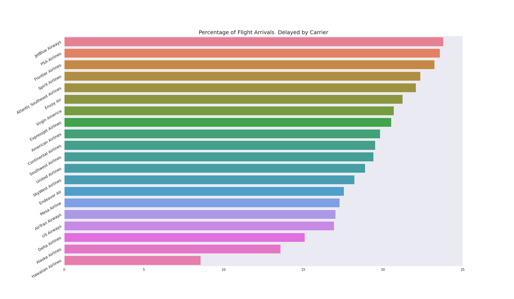

```python
plt.figure(figsize=(24,14))

ax=sns.barplot(airline_arr_delay_df,x="perc_ArrDel15",y="CarrierName" ,hue="CarrierName")

ax.set_title("Percentage of Flight Arrivals  Delayed by Carrier", size=18)


ax.set(xlabel=None)
ax.set(ylabel=None)

ax.tick_params(axis='x',labelsize =11)
ax.tick_params(axis='y',labelrotation=30,labelsize=13)
sns.set_style("dark")

plt.xlim(0, 25)

plt.show()
%matplot plt
```

```python
# Calculate the percentage of DepDel15 equal to 1 grouped by Airline
query = """
SELECT
     CarrierName,
    ROUND((SUM(CASE WHEN DepDel15 = '1' THEN 1 ELSE 0 END) / COUNT(*) * 100),2) AS perc_DepDel15
FROM
    data_explore
GROUP BY
     CarrierName

ORDER BY perc_DepDel15 DESC
"""

depart_delay_pct = spark.sql(query)
```

```
VBox()
```

```
FloatProgress(value=0.0, bar_style='info', description='Progress:', layout=Layout(height='25px', width='50%'),…
```

```python
DepDel_carrier_df=depart_delay_pct.toPandas()
```

```
VBox()
```

```
FloatProgress(value=0.0, bar_style='info', description='Progress:', layout=Layout(height='25px', width='50%'),…
```

```
VBox()
```

```
FloatProgress(value=0.0, bar_style='info', description='Progress:', layout=Layout(height='25px', width='50%'),…
```

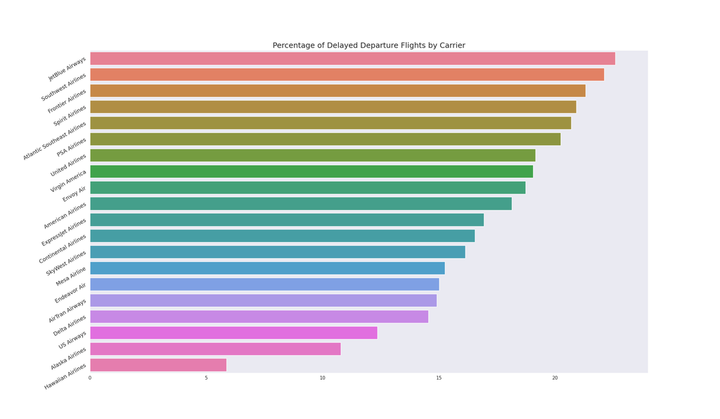

```python
plt.figure(figsize=(24,14))

ax=sns.barplot(DepDel_carrier_df,x="perc_DepDel15",y="CarrierName" ,hue="CarrierName")

ax.set_title("Percentage of Delayed Departure Flights by Carrier", size=18)


ax.set(xlabel=None)
ax.set(ylabel=None)

ax.tick_params(axis='x',labelsize =11)
ax.tick_params(axis='y',labelrotation=30,labelsize=13)
sns.set_style("dark")

plt.xlim(0, 24)

plt.show()
%matplot plt
```

```python
#Calculate the Average minutes departure delayed grouped by Airline
query = """
SELECT
     CarrierName,
    ROUND(AVG(DEP_DELAY),2) AS avg_DepDelMinutes
FROM
    data_explore
GROUP BY
     CarrierName


ORDER BY avg_DepDelMinutes DESC
"""


depart_delay_min = spark.sql(query)
```

```
VBox()
```

```
FloatProgress(value=0.0, bar_style='info', description='Progress:', layout=Layout(height='25px', width='50%'),…
```

```python
DelMin_carrier_df=depart_delay_min.toPandas()
```

```
VBox()
```

```
FloatProgress(value=0.0, bar_style='info', description='Progress:', layout=Layout(height='25px', width='50%'),…
```

```
VBox()
```

```
FloatProgress(value=0.0, bar_style='info', description='Progress:', layout=Layout(height='25px', width='50%'),…
```

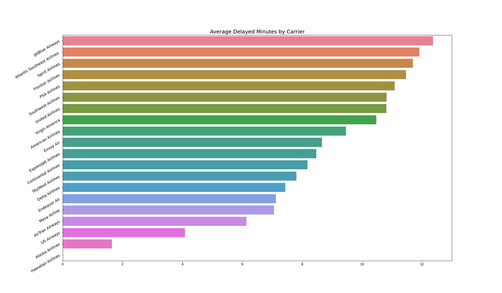

```python
plt.figure(figsize=(24,14))

ax=sns.barplot(DelMin_carrier_df,x="avg_DepDelMinutes",y="CarrierName" ,hue="CarrierName")

ax.set_title("Average Delayed Minutes by Carrier", size=18)


ax.set(xlabel=None)
ax.set(ylabel=None)

ax.tick_params(axis='x',labelsize =11)
ax.tick_params(axis='y',labelrotation=30,labelsize=13)
sns.set_style("dark")

plt.xlim(0, 13)

plt.show()
%matplot plt
```

The percentage of flight delays remained consistent with only the years 2013 and 2014 having flight arrival delays greater than twenty percent.

Viewing the bar plots for departure and arrival delays we find that though Jet Blue only accounts for four percent of total domestic flights it ranks on top for both percentage of delayed departures and delayed arrivals of fifteen minutes or more.

Checking the average delayed minutes, it’s not surprising that the airlines follow closely the order of the following two plots.

```python
#Calculate the Average Carrier Delay Minutes minutes  grouped by Airline
query = """
SELECT
     CarrierName,
    ROUND(AVG(CARRIER_DELAY),2) AS avg_CarrierDelMinutes
FROM
    data_explore
GROUP BY
     CarrierName


ORDER BY avg_CarrierDelMinutes DESC
"""

carrier_delay_min = spark.sql(query)
```

```
VBox()
```

```
FloatProgress(value=0.0, bar_style='info', description='Progress:', layout=Layout(height='25px', width='50%'),…
```

```python
carrier_delay_min.show(20)
```

```
VBox()
```

```
FloatProgress(value=0.0, bar_style='info', description='Progress:', layout=Layout(height='25px', width='50%'),…
```

```
+--------------------+---------------------+
|         CarrierName|avg_CarrierDelMinutes|
+--------------------+---------------------+
|Atlantic Southeas...|                 4.93|
|        PSA Airlines|                 4.84|
|     JetBlue Airways|                 4.71|
|        Mesa Airline|                 4.22|
|   American Airlines|                 3.96|
|        Endeavor Air|                 3.45|
|           Envoy Air|                 3.44|
|     United Airlines|                 3.36|
|      Delta Airlines|                 3.34|
|   Frontier Airlines|                 3.33|
|    SkyWest Airlines|                 3.29|
| ExpressJet Airlines|                  3.2|
|Continental Airlines|                 3.17|
|     Spirit Airlines|                 2.87|
|  Southwest Airlines|                 2.72|
|          US Airways|                 2.57|
|   Hawaiian Airlines|                 2.42|
|      Virgin America|                 2.18|
|     Alaska Airlines|                 1.95|
|     AirTran Airways|                 1.73|
+--------------------+---------------------+
```

```python
#Calculate the Average Late Aircraft Delay  minutes  grouped by Airline
query = """
SELECT
     CarrierName,
    ROUND(AVG(LATE_AIRCRAFT_DELAY),2) AS avg_Late_aircraftDelMinutes
FROM
    data_explore
GROUP BY
     CarrierName


ORDER BY avg_Late_aircraftDelMinutes DESC
"""

LateAircraft_delay_min = spark.sql(query)
```

```
VBox()
```

```
FloatProgress(value=0.0, bar_style='info', description='Progress:', layout=Layout(height='25px', width='50%'),…
```

```python
Late_aircraft_df=LateAircraft_delay_min.toPandas()
```

```
VBox()
```

```
FloatProgress(value=0.0, bar_style='info', description='Progress:', layout=Layout(height='25px', width='50%'),…
```

```
VBox()
```

```
FloatProgress(value=0.0, bar_style='info', description='Progress:', layout=Layout(height='25px', width='50%'),…
```

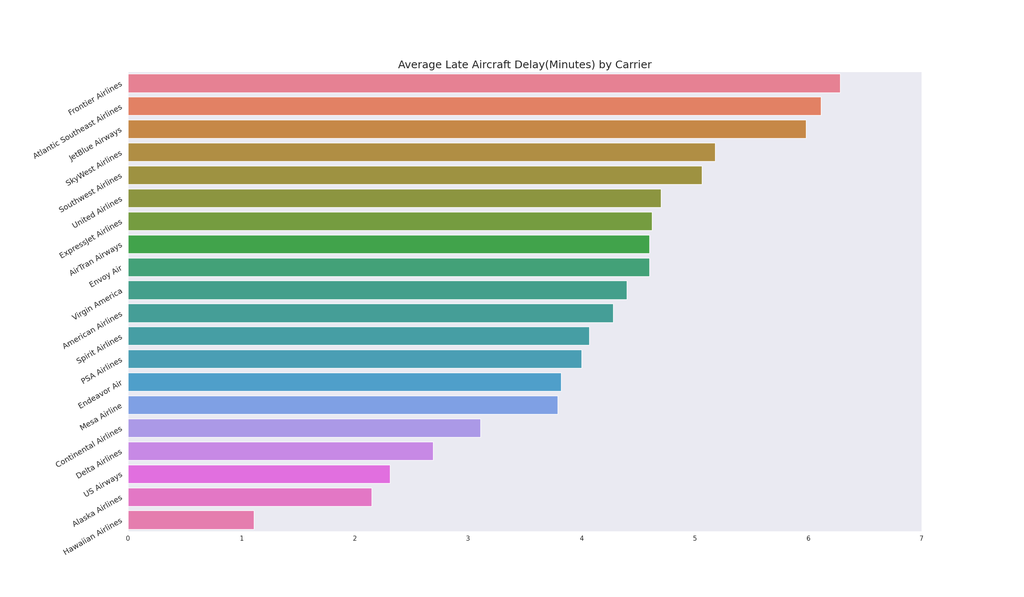

```python
plt.figure(figsize=(24,14))

ax=sns.barplot(Late_aircraft_df,x="avg_Late_aircraftDelMinutes",y="CarrierName" ,hue="CarrierName")

ax.set_title("Average Late Aircraft Delay(Minutes) by Carrier", size=18)


ax.set(xlabel=None)
ax.set(ylabel=None)

ax.tick_params(axis='x',labelsize =11)
ax.tick_params(axis='y',labelrotation=30,labelsize=13)
sns.set_style("dark")

plt.xlim(0, 7)

plt.show()
%matplot plt
```

Analyzing carrier delays we observe the sane airlines at the top except for Mesa Airlines which has been nears the lower end of the previous plots. Viewing the average delayed aircraft plot, as with the previous plots and tables, we find the same airlines at the top except for SkyWest. SkyWest has been in the middle of the pack for the previous tables and plots.

```python
#Calculate flight count and flight percent by Origin Airport
query = """
SELECT
    ORIGIN,
    COUNT(*) AS originAirport_count,
    ROUND(COUNT(*) / SUM(COUNT(*)) OVER () * 100, 2) AS originAirport_perc
FROM
    data_explore
GROUP BY
    ORIGIN
ORDER BY
    originAirport_perc DESC

"""

origin_airportCntPct = spark.sql(query)
```

```
VBox()
```

```
FloatProgress(value=0.0, bar_style='info', description='Progress:', layout=Layout(height='25px', width='50%'),…
```

```python
origin_airportCntPct.show(388)
```

```
VBox()
```

```
FloatProgress(value=0.0, bar_style='info', description='Progress:', layout=Layout(height='25px', width='50%'),…
```

```
+------+-------------------+------------------+
|ORIGIN|originAirport_count|originAirport_perc|
+------+-------------------+------------------+
|   ATL|            3849391|              6.37|
|   ORD|            2915085|              4.82|
|   DFW|            2488904|              4.12|
|   DEN|            2271450|              3.76|
|   LAX|            2106537|              3.49|
|   PHX|            1705697|              2.82|
|   IAH|            1645926|              2.72|
|   SFO|            1580093|              2.61|
|   LAS|            1458937|              2.41|
|   CLT|            1312686|              2.17|
|   DTW|            1270314|               2.1|
|   MSP|            1242835|              2.06|
|   MCO|            1211759|              2.01|
|   EWR|            1142181|              1.89|
|   BOS|            1142332|              1.89|
|   SLC|            1136832|              1.88|
|   SEA|            1134063|              1.88|
|   LGA|            1036250|              1.71|
|   JFK|            1031656|              1.71|
|   BWI|             985333|              1.63|
|   MDW|             855213|              1.42|
|   PHL|             817485|              1.35|
|   DCA|             789719|              1.31|
|   SAN|             786897|               1.3|
|   MIA|             741299|              1.23|
|   FLL|             726102|               1.2|
|   TPA|             678334|              1.12|
|   IAD|             590942|              0.98|
|   STL|             559879|              0.93|
|   BNA|             555012|              0.92|
|   PDX|             549651|              0.91|
|   DAL|             546167|               0.9|
|   HOU|             543449|               0.9|
|   HNL|             503991|              0.83|
|   MCI|             473729|              0.78|
|   AUS|             463172|              0.77|
|   OAK|             467480|              0.77|
```

[output cut: 327 more lines]

```
|   LCK|               1072|               0.0|
|   MVY|               1753|               0.0|
|   LWB|               1645|               0.0|
|   FLO|               1147|               0.0|
|   SLN|                670|               0.0|
|   LYH|               2781|               0.0|
|   PSM|                297|               0.0|
|   USA|                976|               0.0|
|   MMH|               1416|               0.0|
|   HVN|                921|               0.0|
|   LBL|                550|               0.0|
|   BLV|               1009|               0.0|
|   WYS|               2575|               0.0|
|   FOE|                418|               0.0|
+------+-------------------+------------------+
```

```python
# Calculate the percentage of DepDel15 equal to 1 grouped by Orginating Airport HAVING COUNT(Airline) > 29000



query = """
SELECT
    ORIGIN,
    ROUND((SUM(CASE WHEN DepDel15 = '1' THEN 1 ELSE 0 END) / COUNT(*) * 100),2) AS perc_OriginDepDel15
FROM
    data_explore
GROUP BY
    ORIGIN

HAVING COUNT(ORIGIN) > 29000

ORDER BY perc_OriginDepDel15 DESC
"""

Origindepart_delay_pct = spark.sql(query)
```

```
VBox()
```

```
FloatProgress(value=0.0, bar_style='info', description='Progress:', layout=Layout(height='25px', width='50%'),…
```

```python
Origindepart_delay_pct.show(50)
```

```
VBox()
```

```
FloatProgress(value=0.0, bar_style='info', description='Progress:', layout=Layout(height='25px', width='50%'),…
```

```
+------+-------------------+
|ORIGIN|perc_OriginDepDel15|
+------+-------------------+
|   MDW|              26.01|
|   HOU|              24.89|
|   EWR|              23.96|
|   DAL|              23.32|
|   ORD|              22.55|
|   SFO|              22.14|
|   BWI|               21.9|
|   ASE|               21.8|
|   DFW|              21.18|
|   MIA|              21.03|
|   DEN|              20.86|
|   FLL|              20.77|
|   LAS|              20.48|
|   JFK|              20.31|
|   PBI|              20.16|
|   STL|              19.88|
|   MFR|              19.86|
|   HPN|              19.42|
|   OAK|               19.3|
|   MCO|              19.26|
|   BNA|              19.21|
|   LGA|              19.12|
|   CRW|              19.08|
|   BTV|              18.95|
|   SJU|              18.91|
|   LAX|               18.9|
|   ATL|              18.45|
|   SAV|              18.44|
|   IAD|               18.4|
|   PHL|              18.22|
|   IAH|              18.05|
|   BTR|              18.05|
|   SBP|              18.04|
|   AVL|              18.02|
|   BOS|              17.99|
|   AGS|              17.88|
|   SDF|              17.31|
|   CAE|              17.28|
|   GSO|              17.28|
|   XNA|              17.28|
|   TPA|              17.27|
|   LIT|              17.25|
|   MYR|              17.15|
|   RDU|              17.14|
|   PWM|              17.13|
|   CHS|               17.1|
|   MSY|              17.08|
|   ABQ|              17.06|
|   TYS|              17.05|
|   PHX|              17.03|
+------+-------------------+
only showing top 50 rows
```

```python
#Calculate the Average TaxiOut grouped by Origin Airport
query = """
SELECT
    Origin,
    ROUND(AVG(TAXI_OUT),2) AS avg_TaxiOutMinutes
FROM
    data_explore
GROUP BY
    Origin
HAVING COUNT(Origin) > 29000

ORDER BY avg_TaxiOutMinutes DESC
"""

avg_OriginTaxiOut = spark.sql(query)
```

```
VBox()
```

```
FloatProgress(value=0.0, bar_style='info', description='Progress:', layout=Layout(height='25px', width='50%'),…
```